# STA437 Project

## Abstraction

This project is used to analyze the data of World Happiness report of 2017 by using multiple linear model and principal components.

## Summary

The dataset is from the World Happiness report of 2017. From the data frame, some values are missing or not avaliable. Before manipulating the data, need to remove those missing values and randomly select 100 countries from the data set.  
Build the linear regression model by using the original data frame. The adjusted R-squared is 0.7775 from the R summary output. Then, build the covariance matrix from the data frame.After having the eigenvalues and eigenvectors of the covariance matrix, we can have the proportion of the variance by each eigenvalue. The first two eigen values are occupied the most proportion, so the we mainly focus on the first two principal components.  
We can also have the correlation matrix for principal component analysis. Then, do the same thing, build the correlation matrix, manipulate the eigenvalues and eigenvectors based on correlation matirx. The scree plots show the proportion of the total variance due to each principal component.  
From the plots, we can find out that PC1 and PC2 are most important, the proportions of PC1 and PC2 are more than 50% of the total variance, so we only select the first two principal components to have a major analysis. To have a multiple linear model using principal components, fit principal components into a linear model. After using R summary(), the adjusted R-squared number is 0.7775.  
From plots, the first two principal components are retained.

## Appendix

```r
library(ggplot2)
library(ggbiplot)
library(corrplot)
library(clusterSim)
library(pls)
happiness2017 <- read.csv(file = 'happiness2017.csv')
#head(happiness2017)
# remove countries with NA values
happ <- na.omit(happiness2017)
set.seed(2741)
# choose 100 random samples from data frame
happ <- happ[sample(nrow(happ), 100),]
# data normalization
happ <- clusterSim::data.Normalization(happ, type = "n1", normalization = "column")
# basic linear model
ml <- lm(Ladder ~ LogGDP + Social + HLE + Freedom + Generosity + Corruption + Positive + Negative + gini,
         data = happ)
summary(ml)
```

```
##
## Call:
## lm(formula = Ladder ~ LogGDP + Social + HLE + Freedom + Generosity +
##     Corruption + Positive + Negative + gini, data = happ)
##
## Residuals:
##      Min       1Q   Median       3Q      Max
## -1.15991 -0.30260 -0.02345  0.34325  1.01175
##
## Coefficients:
##               Estimate Std. Error t value Pr(>|t|)
## (Intercept)  3.249e-16  4.717e-02   0.000 1.000000
## LogGDP       4.078e-01  1.053e-01   3.874 0.000203 ***
## Social       2.332e-01  8.332e-02   2.799 0.006279 **
## HLE          1.793e-01  1.007e-01   1.781 0.078225 .
## Freedom      1.462e-01  6.290e-02   2.324 0.022358 *
## Generosity   1.139e-01  5.411e-02   2.106 0.038002 *
## Corruption   3.108e-03  6.157e-02   0.050 0.959853
## Positive     1.510e-01  6.380e-02   2.367 0.020059 *
## Negative     1.018e-01  6.551e-02   1.554 0.123687
## gini        -9.478e-02  6.929e-02  -1.368 0.174769
## ---
## Signif. codes:  0 '***' 0.001 '**' 0.01 '*' 0.05 '.' 0.1 ' ' 1
##
## Residual standard error: 0.4717 on 90 degrees of freedom
## Multiple R-squared:  0.7978, Adjusted R-squared:  0.7775
## F-statistic: 39.44 on 9 and 90 DF,  p-value: < 2.2e-16
```

```r
# calculation
# covariance matrix of the data
cov.matrix <- cov(happ[,3:11])
# total variance
#sum(diag(cov.matrix))
# calculate the eigenvalues and
# corresponding eigenvectors of the cov.matrix
cov.eigen <- eigen(cov.matrix)
cov.eigen
```

```
## eigen() decomposition
## $values
## [1] 3.8824712 1.9497501 0.7841795 0.6945802 0.5628992 0.4592552 0.3096561
## [8] 0.2356385 0.1215700
##
## $vectors
##              [,1]        [,2]         [,3]        [,4]        [,5]        [,6]
##  [1,] -0.44359666  0.15537003  0.045356332  0.02191506 -0.42780600  0.05037737
##  [2,] -0.42467665  0.13484665 -0.298559378  0.14096217 -0.03339004  0.23840709
##  [3,] -0.43683199  0.17611324  0.146790090  0.17409067 -0.31192951 -0.09778241
##  [4,] -0.28255300 -0.42069716 -0.047852903 -0.22561190  0.10842457 -0.78273006
##  [5,] -0.06395321 -0.49039086  0.280471581  0.78180497  0.19002237  0.09818732
##  [6,]  0.25841254  0.35555110 -0.601963726  0.39919623  0.16618977 -0.27908320
##  [7,] -0.26529253 -0.38460035 -0.637563795  0.03104572 -0.07051779  0.13205526
##  [8,]  0.38059702 -0.04451366 -0.005187287  0.26094825 -0.73967333 -0.30498462
##  [9,]  0.25712272 -0.48257215 -0.193465075 -0.24250079 -0.30165260  0.34700727
##              [,7]        [,8]        [,9]
##  [1,]  0.18850713 -0.19382443  0.71964296
##  [2,]  0.37990220  0.65959431 -0.23476568
##  [3,] -0.02015442 -0.47901408 -0.62416739
##  [4,]  0.24308450  0.08037768  0.00376778
##  [5,]  0.09683817 -0.02773389  0.09822128
##  [6,]  0.29257966 -0.29855743  0.06958838
##  [7,] -0.58536992 -0.08833921  0.03712015
##  [8,] -0.15823615  0.34288733 -0.04796761
##  [9,]  0.54586262 -0.27599119 -0.13867657
```

```r
# The eigenvectors represent the
# principal components of cov.matrix
# The eigenvalues of cov.matrix
# are used to find the proportion of the
# total variance explained by the components.
for(s in cov.eigen$values){
  print(s / sum(cov.eigen$values))
}
```

```
## [1] 0.4313857
## [1] 0.2166389
## [1] 0.08713106
## [1] 0.07717558
## [1] 0.06254436
## [1] 0.05102835
## [1] 0.03440624
## [1] 0.02618205
## [1] 0.01350777
```

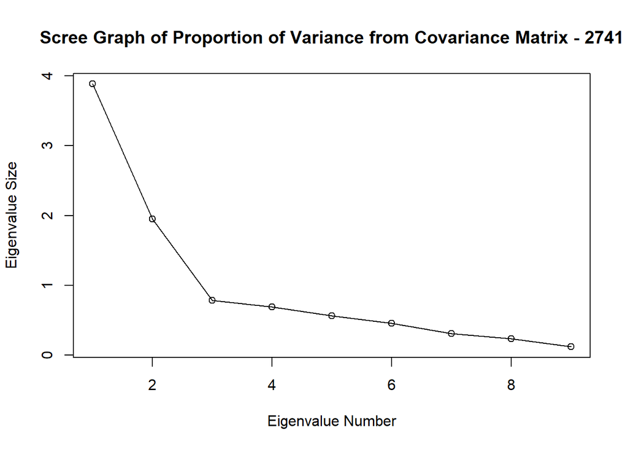

```r
#plot the proportion of variance
plot(cov.eigen$values,
     xlab = "Eigenvalue Number",
     ylab = "Eigenvalue Size",
     main = "Scree Graph of Proportion of Variance from Covariance Matrix - 2741")
lines(cov.eigen$values)
```

```r
# eigenvectors of covariance matrix
cov.eigen$vectors
```

```
##              [,1]        [,2]         [,3]        [,4]        [,5]        [,6]
##  [1,] -0.44359666  0.15537003  0.045356332  0.02191506 -0.42780600  0.05037737
##  [2,] -0.42467665  0.13484665 -0.298559378  0.14096217 -0.03339004  0.23840709
##  [3,] -0.43683199  0.17611324  0.146790090  0.17409067 -0.31192951 -0.09778241
##  [4,] -0.28255300 -0.42069716 -0.047852903 -0.22561190  0.10842457 -0.78273006
##  [5,] -0.06395321 -0.49039086  0.280471581  0.78180497  0.19002237  0.09818732
##  [6,]  0.25841254  0.35555110 -0.601963726  0.39919623  0.16618977 -0.27908320
##  [7,] -0.26529253 -0.38460035 -0.637563795  0.03104572 -0.07051779  0.13205526
##  [8,]  0.38059702 -0.04451366 -0.005187287  0.26094825 -0.73967333 -0.30498462
##  [9,]  0.25712272 -0.48257215 -0.193465075 -0.24250079 -0.30165260  0.34700727
##              [,7]        [,8]        [,9]
##  [1,]  0.18850713 -0.19382443  0.71964296
##  [2,]  0.37990220  0.65959431 -0.23476568
##  [3,] -0.02015442 -0.47901408 -0.62416739
##  [4,]  0.24308450  0.08037768  0.00376778
##  [5,]  0.09683817 -0.02773389  0.09822128
##  [6,]  0.29257966 -0.29855743  0.06958838
##  [7,] -0.58536992 -0.08833921  0.03712015
##  [8,] -0.15823615  0.34288733 -0.04796761
##  [9,]  0.54586262 -0.27599119 -0.13867657
```